# **Predicting White Wine Alcohol Content and Quality from Physicochemical Properties**

Laraine Ukwu-George

30/11/2025

# Main Findings

- Alcohol content was the strongest predictor of wine quality (r = 0.46, p < 0.001), followed by density (r = -0.32) and chlorides (r = -0.19). pH and citric acid had minimal impact on quality.
- Multicollinearity was identified between density and residual sugar (r = 0.79), and density and total sulfur dioxide (r = 0.51). These variables were removed, achieving VIF < 5 for all remaining predictors.
- Based on the simple linear model alcohol = 348.032 - 339.562 * density, 60% of alcohol content variability is explained by density. With p-value < 0.05, the negative relationship is significant, however the model failed the linearity test due to alcohol’s non-normal distribution.
- With adjusted $R^2$ = 0.71 (AIC = 1015.55), the best multiple linear regression model was alcohol = 296.67 + 0.135 * fixed.acidity + 1.439 * volatile.acidity + 0.661 * citric.acid - 11.454 * chlorides - 293.605 * density + 0.897 * pH + 0.309 * quality. Density was the dominant predictor ($\beta$ = -293.61, p < 0.001).
- The best logistic model for predicting good and bad wines (AIC = 526.39) was log(p/1-p) = -8.731 - 4.615 * volatile.acidity + 7.739 * chlorides + 1.001 * alcohol. Alcohol was the most significant predictor while chlorides were not significant (p > 0.05). Each unit increase in alcohol raised odds of good quality by 118-245%, while increases in volatile acidity decreased odds by 89-100%.
- Confusion matrix showed 286 true positives and 83 true negatives (accuracy = 73.8%, sensitivity = 0.85, specificity = 0.50), indicating better classification performance for good wines than poor wines, likely arising from the 67:33 class imbalance in the sample.
- Binary quality classification achieved 73.8% accuracy with Kappa = 0.376, indicating the model performs 37.6% better than random guessing. The modest Kappa value suggests room for improvement with larger and more balanced sample sizes.
- Physicochemical properties, particularly alcohol content and density, provide objective predictors of wine quality, validating the use of laboratory measurements for quality assessment.

# Executive Summary

This analysis examines 500 white wine samples simulated from the UCI Machine Learning Repository dataset to predict alcohol content and quality from physicochemical properties. Using smoothed bootstrapping to preserve correlation structures, the study addresses two research questions: can chemical properties predict alcohol content, and can they classify wine quality? Multiple regression and logistic regression approaches were employed, with 10-fold cross-validation for model validation. After addressing multicollinearity by removing residual sugar and total sulfur dioxide (both highly correlated with density), the multiple linear regression model explained 71% of alcohol content variation, with density as the strongest predictor. The logistic regression model successfully classified wines as good (quality ≥6) or poor (quality <6) with 73.8% accuracy, 85.4% sensitivity and 50.3% specificity, indicating strong discriminatory power for good wines but weaker performance for poor wines. Alcohol content emerged as the primary quality indicator, with each unit increase raising the odds of good quality by 118-245%. The findings demonstrate that objective physicochemical measurements can effectively predict both alcohol content and quality ratings, providing practical implications for wine production and quality control processes. However, the modest Kappa statistic (0.376) and low specificity (0.503) suggest opportunities for improvement with larger and balanced datasets.

# Introduction

White wine is an alcoholic beverage produced from fermented grapes and is enjoyed worldwide, with high-quality wines commanding premium prices in international markets. Quality assessment directly impacts producer reputation and economic returns, making accurate quality prediction essential for the wine industry. Traditionally, wine quality is assessed through sensory evaluation by trained experts who evaluate characteristics such as acidity, body, crispness, and aroma. However, this approach is inherently subjective, prone to assessor variability, and susceptible to fatigue effects when evaluating multiple samples (Cortez et al. 2009). These limitations create a need for objective, reproducible quality assessment methods based on measurable physicochemical properties that can be determined through standardized laboratory analysis. This analysis uses a simulated dataset of 500 observations derived from the UCI Machine Learning Repository white wine quality dataset (Cortez et al., 2009), containing 12 variables related to wine physicochemistry. Key variables include alcohol content, density, chlorides, citric acid, fixed acidity, volatile acidity, pH, and sulphates, with quality (assessed on a 3-9 scale) as the response variable. This study addresses three research aims:

Examine relationships between physicochemical properties and wine quality Predict alcohol content from other chemical properties Evaluate predictive model performance for quality classification

To address these aims, smoothed bootstrapping simulates the data while preserving correlation structures. Correlation matrices investigate relationships and inform feature selection. Multiple linear regression predicts alcohol content, while logistic regression classifies wine quality. Hypothesis tests provide inferential statistics, and 10-fold cross-validation assesses model performance

# RESULTS

## Validation, Exploratory Data Analysis and Preprocessing

Initial exploration of the original dataset (see Appendix Figures A1-A2) provided various parameters including distributions, correlations, and summary statistics. Descriptive statistics of the simulated dataset were compared to those of the original and they appeared similar. Table 1 shows one example of such comparisons.

Table 1: Comparing original and simulated means

|  | Original_Mean | Simulated_Mean |
| --- | --- | --- |
| fixed.acidity | 6.85 | 6.79 |
| volatile.acidity | 0.28 | 0.27 |
| citric.acid | 0.33 | 0.33 |
| residual.sugar | 6.39 | 6.11 |
| chlorides | 0.05 | 0.05 |
| free.sulfur.dioxide | 35.31 | 36.18 |
| total.sulfur.dioxide | 138.36 | 139.10 |
| density | 0.99 | 0.99 |
| pH | 3.19 | 3.20 |
| sulphates | 0.49 | 0.49 |
| alcohol | 10.51 | 10.54 |

Data Frame Summary

wine_sim

**Dimensions**: 500 x 12  
**Duplicates**: 0

| **No** | **Variable** | **Stats / Values** | **Freqs (% of Valid)** | **Graph** | **Valid** | **Missing** |
| --- | --- | --- | --- | --- | --- | --- |
| 1 | fixed.acidity [numeric] | Mean (sd) : 6.8 (0.9) min ≤ med ≤ max: 4.5 ≤ 6.7 ≤ 9.9 IQR (CV) : 1.1 (0.1) | 500 distinct values |  | 500 (100.0%) | 0 (0.0%) |
| 2 | volatile.acidity [numeric] | Mean (sd) : 0.3 (0.1) min ≤ med ≤ max: 0.1 ≤ 0.3 ≤ 0.7 IQR (CV) : 0.1 (0.3) | 500 distinct values |  | 500 (100.0%) | 0 (0.0%) |
| 3 | citric.acid [numeric] | Mean (sd) : 0.3 (0.1) min ≤ med ≤ max: 0 ≤ 0.3 ≤ 0.7 IQR (CV) : 0.1 (0.3) | 500 distinct values |  | 500 (100.0%) | 0 (0.0%) |
| 4 | residual.sugar [numeric] | Mean (sd) : 6.1 (4.9) min ≤ med ≤ max: -0.4 ≤ 5.2 ≤ 23.8 IQR (CV) : 7.1 (0.8) | 500 distinct values |  | 500 (100.0%) | 0 (0.0%) |
| 5 | chlorides [numeric] | Mean (sd) : 0 (0) min ≤ med ≤ max: 0 ≤ 0 ≤ 0.2 IQR (CV) : 0 (0.5) | 500 distinct values |  | 500 (100.0%) | 0 (0.0%) |
| 6 | free.sulfur.dioxide [numeric] | Mean (sd) : 36.2 (16.9) min ≤ med ≤ max: 1.7 ≤ 33.3 ≤ 129.9 IQR (CV) : 23.1 (0.5) | 500 distinct values |  | 500 (100.0%) | 0 (0.0%) |
| 7 | total.sulfur.dioxide [numeric] | Mean (sd) : 139.1 (40.4) min ≤ med ≤ max: 14.4 ≤ 136 ≤ 308.6 IQR (CV) : 56.5 (0.3) | 500 distinct values |  | 500 (100.0%) | 0 (0.0%) |
| 8 | density [numeric] | Mean (sd) : 1 (0) min ≤ med ≤ max: 1 ≤ 1 ≤ 1 IQR (CV) : 0 (0) | 500 distinct values |  | 500 (100.0%) | 0 (0.0%) |
| 9 | pH [numeric] | Mean (sd) : 3.2 (0.2) min ≤ med ≤ max: 2.8 ≤ 3.2 ≤ 3.8 IQR (CV) : 0.2 (0.1) | 500 distinct values |  | 500 (100.0%) | 0 (0.0%) |
| 10 | sulphates [numeric] | Mean (sd) : 0.5 (0.1) min ≤ med ≤ max: 0.3 ≤ 0.5 ≤ 1 IQR (CV) : 0.1 (0.2) | 500 distinct values |  | 500 (100.0%) | 0 (0.0%) |
| 11 | alcohol [numeric] | Mean (sd) : 10.5 (1.2) min ≤ med ≤ max: 8.2 ≤ 10.3 ≤ 13.6 IQR (CV) : 2 (0.1) | 500 distinct values |  | 500 (100.0%) | 0 (0.0%) |
| 12 | quality [integer] | Mean (sd) : 5.9 (0.9) min ≤ med ≤ max: 3 ≤ 6 ≤ 9 IQR (CV) : 1 (0.1) | 3 : 1 ( 0.2% ) 4 : 11 ( 2.2% ) 5 : 153 ( 30.6% ) 6 : 225 ( 45.0% ) 7 : 94 ( 18.8% ) 8 : 15 ( 3.0% ) 9 : 1 ( 0.2% ) |  | 500 (100.0%) | 0 (0.0%) |

Generated by summarytools 1.1.4 ([R](https://www.r-project.org/) version 4.4.1)  
2025-12-10

Upon binary classification of the wine dataset, 33% were poor quality wines and 67% were good quality wines as shown in Figure 2. This imbalance has the potential to affect the logistic model’s ability to predict poor wines.

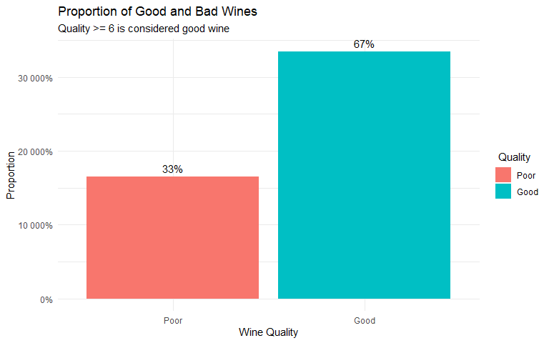

Figure 2: Proportion of Good and Bad Wines

The boxplot below investigates outliers and median values. Chlorides and volatile acidity have many outliers indicative of unusually high values for these properties. The median values between groups do not vary much apart from alcohol, density and volatile acidity.

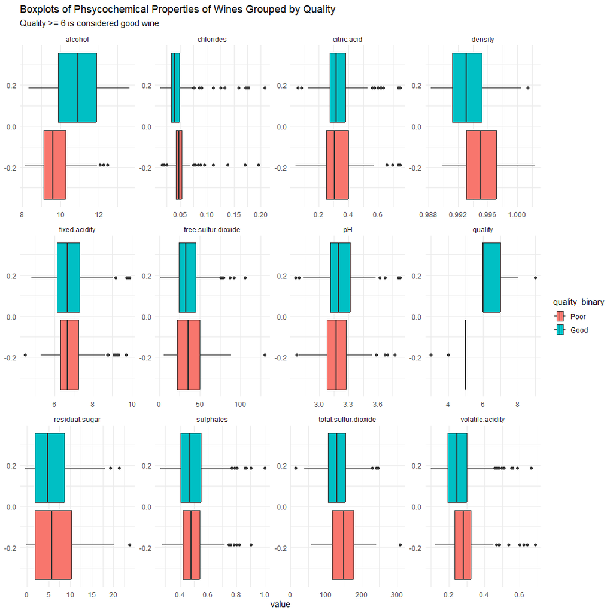

Figure 3: Boxplots of Physicochemical of White Wine Grouped by Quality